# DATA624-HW1-TimeSeries

FPP-Hyndman exercises 2.1, 2.2, 2.3, 2.6

Michael Y.

2/09/2020

```r
library(fpp2)
```

# Homework 1 - Time Series

Please submit exercises 2.1, 2.2, 2.3 and 2.6 from the Hyndman online Forecasting book.  
Please submit both your Rpubs link as well as attach the .rmd file with your code.

## 2.1 Use the help function to explore what the series `gold`, `woolyrnq` and `gas` represent.

```r
### Gold
help(gold)
```

```
## starting httpd help server ... done
```

```r
gold.title <- "Daily morning gold prices in US dollars. 1 January 1985 – 31 March 1989."

### Woolyrnq
help(woolyrnq)
woolyrnq.title <- "Quarterly production of woollen yarn in Australia: tonnes. Mar 1965 – Sep 1994."

### Gas
help(gas)
gas.title <- "Australian monthly gas production: 1956–1995."
```

##### The `gold` series represents Daily morning gold prices in US dollars. 1 January 1985 – 31 March 1989.

##### The `woolyrnq` series represents Quarterly production of woollen yarn in Australia: tonnes. Mar 1965 – Sep 1994.

##### The `gas` series represents Australian monthly gas production: 1956–1995.

### a. Use `autoplot()` to plot each of these in separate plots.

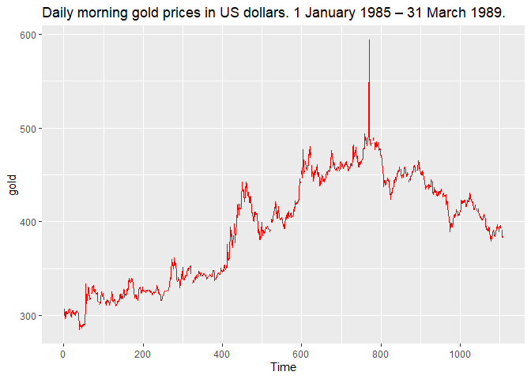

```r
autoplot(gold) + ggtitle(gold.title) + geom_line(color="red")
```

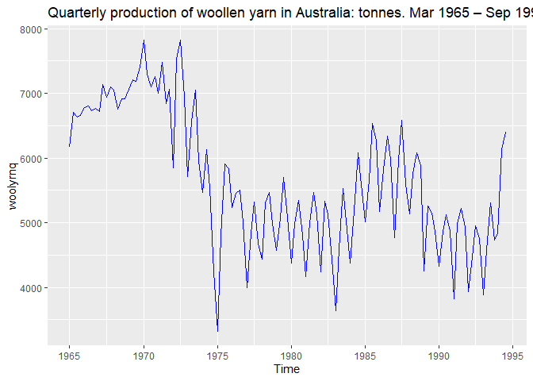

```r
autoplot(woolyrnq) + ggtitle(woolyrnq.title) + geom_line(color="blue")
```

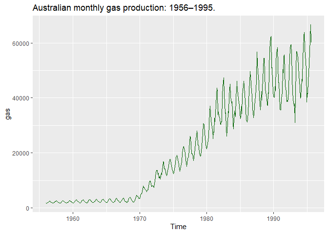

```r
autoplot(gas) + ggtitle(gas.title) + geom_line(color="darkgreen")
```

### b. What is the frequency of each series? Hint: apply the frequency() function.

```r
## Frequency - gold
(gold.freq <- frequency(gold))
```

```
## [1] 1
```

```r
## Frequency - woolyrnq
(woolyrnq.freq <- frequency(woolyrnq))
```

```
## [1] 4
```

```r
## Frequency - gas
(gas.freq <- frequency(gas))
```

```
## [1] 12
```

#### The series for `gold` is stored with frequency = 1, which suggests “Annual”, but the frequency is actually daily(Weekday), i.e, 5 days per week, or 260 observations per year.

#### The frequency for `woolyrnq` is 4, which corresponds to Quarterly.

#### The frequency for `gas` is 12, which corresponds to Monthly.

### c. Use which.max() to spot the outlier in the gold series. Which observation was it?

```r
(gold.max.obs <- which.max(gold))
```

```
## [1] 770
```

```r
(gold.max.val <- gold[gold.max.obs])
```

```
## [1] 593.7
```

#### The outlier is observation number 770, for which the associated price is 593.7 .

#### The data includes `NA` values for holidays such as New Years Day, Good Friday, Easter Monday, Christmas, Boxing Day, and the Bank Holiday which occur on Mondays at the beginning and end of May, and at the end of August.

#### The problem with using “ts” as the data structure for weekday-only data is that Saturdays and Sundays have been omitted, but `ts` requires data to be equally spaced.

#### There are 1108 items in the `gold` data set, of which 34 are `NA` .

#### This corresponds to the number of weekdays from 1/2/1985 through 3/31/1989, inclusive. (January 1, 1985 has been omitted from the dataset, otherwise the first observatious would be `NA` .)

#### We can create a sequence of dates which correspond to the observations, and make a plot which better labels the dates:

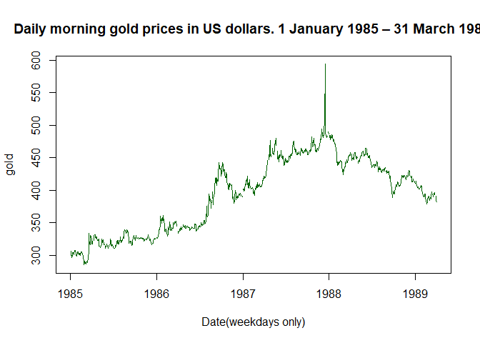

```r
gold.days     <- seq( as.Date("1985/1/2", format="%Y/%m/%d"),
                      as.Date("1989/3/31", format="%Y/%m/%d"),"days")
gold.weekdays <- gold.days[ ! weekdays(gold.days) %in% c("Saturday", "Sunday") ]
plot(x=gold.weekdays,y=gold,type="l",col="darkgreen",
     xlab="Date(weekdays only)",main=gold.title)
```

#### We can get a similar graph by putting the data into a `ts` object while specifying 260 observations per year:

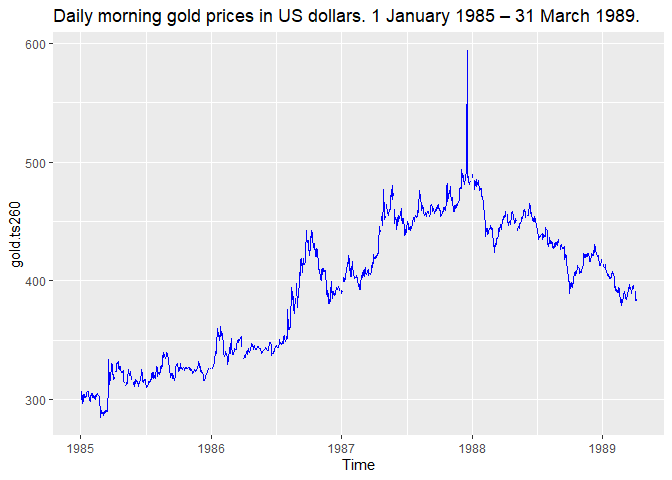

```r
gold.ts260 <- ts(gold,start=c(1985,2),frequency = 260)
autoplot(gold.ts260) + ggtitle(gold.title) + geom_line(color="blue")
```

#### We can put the dates and prices into a data frame, and we can observe the date associated with the outlier:

```r
gold.df       <- data.frame(gold.weekdays,gold)
gold.df[gold.max.obs,]
```

```
##     gold.weekdays  gold
## 770    1987-12-15 593.7
```

## 2.2. Download the file `tute1.csv` from the book website, open it in Excel (or some other spreadsheet application), and review its contents. You should find four columns of information.

### Columns *B* through *D* each contain a quarterly series, labelled `Sales`, `AdBudget` and `GDP`.

- `Sales` contains the quarterly sales for a small company over the period 1981-2005.
- `AdBudget` is the advertising budget and
- `GDP` is the gross domestic product.

All series have been adjusted for inflation.

### a. You can read the data into R with the following script:

```r
tute1 <- read.csv("tute1.csv", header=TRUE)
View(tute1)

## we can load from web, below
##tute11 <- readr::read_csv("https://otexts.com/fpp3/extrafiles/tute1.csv")
##View(tute11)
```

### b. Convert the data to time series

```r
mytimeseries <- ts(tute1[,-1], start=1981, frequency=4)
```

(The [,-1] removes the first column which contains the quarters as we don’t need them now.)

### c. Construct time series plots of each of the three series

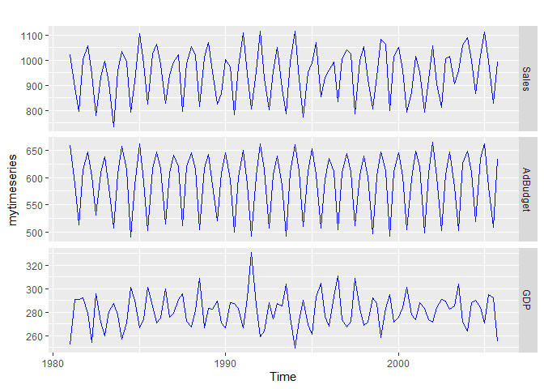

```r
autoplot(mytimeseries, facets=TRUE) + geom_line(color=c("blue"))
```

#### Check what happens when you don’t include `facets=TRUE`.

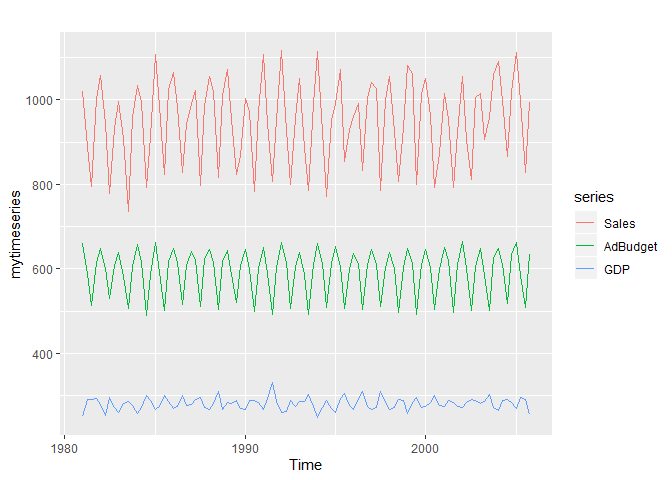

```r
autoplot(mytimeseries, facets=F)
```

If omitting “facets=TRUE”, then all three series are plotted on the same axes. In this case because the values of the data do not intersect each other, the results can still be clearly observed. However, for other data sets with data of very different magnitudes, the result could be a graph which may not allow for easy viewing of the smallest data set.

## 2.3. Download some monthly Australian retail data from the book website. These represent retail sales in various categories for different Australian states, and are stored in a MS-Excel file.

### a. You can read the data into R with the following script:

```r
#### readxl does not read straight from URL without local download
####retaildata <- readxl::read_excel("https://otexts.com/fpp2/extrafiles/retail.xlsx", skip=1)
retaildata <- readxl::read_excel("retail.xlsx", skip=1)
View(retaildata)
```

The second argument (`skip=1`) is required because the Excel sheet has two header rows.

### b. Select one of the time series as follows (but replace the column name with your own chosen column):

#### The rightmost column: A3349396W: “Turnover;Total(State);Total(Industry)”

```r
mycode <- "A3349396W"
mytitle <-  "Monthly Turnover;Total(State);Total(Industry)"
mymain <- paste(mycode,mytitle)
myts <- ts(retaildata[,"A3349396W"],
  frequency=12, start=c(1982,4))
```

### c. Explore your chosen retail time series using the following functions:

`autoplot()`, `ggseasonplot()`, `ggsubseriesplot()`, `gglagplot()`, `ggAcf()`

#### Autoplot

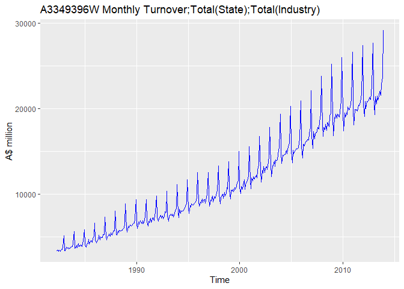

```r
autoplot(object=myts)+
  geom_line(color=c("blue"))+
  ylab("A$ million") +
  ggtitle(mymain)
```

##### The above plot shows very strong annual seasonality in addition to an upward YOY (Year-over-year) trend.